# temp-160656227393944438

**Mushroom Classification**

The link of the dataset and its description - https://www.kaggle.com/uciml/mushroom-classification

**1.Using Sklearn Library**

Scikit-learn is an open source Python library that implements a range of machine learning, pre-processing, cross-validation and visualization algorithms using a unified interface.

1.Important features of scikit-learn:

2.Simple and efficient tools for data mining and data analysis.

3.It features various classification, regression and clustering algorithms including support vector machines, random forests, gradient boosting, k-means, etc.

4.Accessible to everybody and reusable in various contexts.

5.Built on the top of NumPy, SciPy, and matplotlib.

6.Open source, commercially usable – BSD license.

```python
import numpy as np # linear algebra
import pandas as pd # data processing
import matplotlib.pyplot as plt
import seaborn as sns
```

```python
# Importing the dataset

data = pd.read_csv('mushrooms.csv')
```

```python
# Viewing the first five rows of dataset

data.head()
```

|  | class | cap-shape | cap-surface | cap-color | bruises | odor | gill-attachment | gill-spacing | gill-size | gill-color | ... | stalk-surface-below-ring | stalk-color-above-ring | stalk-color-below-ring | veil-type | veil-color | ring-number | ring-type | spore-print-color | population | habitat |
| --- | --- | --- | --- | --- | --- | --- | --- | --- | --- | --- | --- | --- | --- | --- | --- | --- | --- | --- | --- | --- | --- |
| 0 | p | x | s | n | t | p | f | c | n | k | ... | s | w | w | p | w | o | p | k | s | u |
| 1 | e | x | s | y | t | a | f | c | b | k | ... | s | w | w | p | w | o | p | n | n | g |
| 2 | e | b | s | w | t | l | f | c | b | n | ... | s | w | w | p | w | o | p | n | n | m |
| 3 | p | x | y | w | t | p | f | c | n | n | ... | s | w | w | p | w | o | p | k | s | u |
| 4 | e | x | s | g | f | n | f | w | b | k | ... | s | w | w | p | w | o | e | n | a | g |

5 rows × 23 columns

```python
#viewing the number of entries.
data.shape[0]
```

```
8124
```

We can see all the columns have categorical value.

We have 22 features (independent variables) and a dependent variable (class).

There are 8124 values in total

We will continue with data preprocessing but lets get some insights of the dataset first ie using exploratory data analysis.

```python
#lets see the type of features in dataset
features = data.columns
print(features)
```

```
Index(['class', 'cap-shape', 'cap-surface', 'cap-color', 'bruises', 'odor',
       'gill-attachment', 'gill-spacing', 'gill-size', 'gill-color',
       'stalk-shape', 'stalk-root', 'stalk-surface-above-ring',
       'stalk-surface-below-ring', 'stalk-color-above-ring',
       'stalk-color-below-ring', 'veil-type', 'veil-color', 'ring-number',
       'ring-type', 'spore-print-color', 'population', 'habitat'],
      dtype='object')
```

```python
# Finding missing values

dataset.isna().sum()
```

```
class                       0
cap-shape                   0
cap-surface                 0
cap-color                   0
bruises                     0
odor                        0
gill-attachment             0
gill-spacing                0
gill-size                   0
gill-color                  0
stalk-shape                 0
stalk-root                  0
stalk-surface-above-ring    0
stalk-surface-below-ring    0
stalk-color-above-ring      0
stalk-color-below-ring      0
veil-type                   0
veil-color                  0
ring-number                 0
ring-type                   0
spore-print-color           0
population                  0
habitat                     0
dtype: int64
```

No misssing values found in the dataset.So next, let us encode the categorical variables.

**Encoding the Categorical Variables**

```python
from sklearn.preprocessing import LabelEncoder

data_encoded = data.copy()
le = LabelEncoder()
for col in data_encoded.columns:
    data_encoded[col] = le.fit_transform(data_encoded[col])

data_encoded.head()
```

|  | class | cap-shape | cap-surface | cap-color | bruises | odor | gill-attachment | gill-spacing | gill-size | gill-color | ... | stalk-surface-below-ring | stalk-color-above-ring | stalk-color-below-ring | veil-type | veil-color | ring-number | ring-type | spore-print-color | population | habitat |
| --- | --- | --- | --- | --- | --- | --- | --- | --- | --- | --- | --- | --- | --- | --- | --- | --- | --- | --- | --- | --- | --- |
| 0 | 1 | 5 | 2 | 4 | 1 | 6 | 1 | 0 | 1 | 4 | ... | 2 | 7 | 7 | 0 | 2 | 1 | 4 | 2 | 3 | 5 |
| 1 | 0 | 5 | 2 | 9 | 1 | 0 | 1 | 0 | 0 | 4 | ... | 2 | 7 | 7 | 0 | 2 | 1 | 4 | 3 | 2 | 1 |
| 2 | 0 | 0 | 2 | 8 | 1 | 3 | 1 | 0 | 0 | 5 | ... | 2 | 7 | 7 | 0 | 2 | 1 | 4 | 3 | 2 | 3 |
| 3 | 1 | 5 | 3 | 8 | 1 | 6 | 1 | 0 | 1 | 5 | ... | 2 | 7 | 7 | 0 | 2 | 1 | 4 | 2 | 3 | 5 |
| 4 | 0 | 5 | 2 | 3 | 0 | 5 | 1 | 1 | 0 | 4 | ... | 2 | 7 | 7 | 0 | 2 | 1 | 0 | 3 | 0 | 1 |

5 rows × 23 columns

**Exploratory Data Analysis**

Let us look upon the various features and their importance.

```python
import matplotlib.pylab as pylab
params = {'legend.fontsize': 'x-large',
         'axes.labelsize': 'x-large',
         'axes.titlesize':'x-large',
         'xtick.labelsize':'x-large',
         'ytick.labelsize':'x-large'}
pylab.rcParams.update(params)
```

```python
def plot_col(col, hue=None, color=['red', 'lightgreen'], labels=None):
    fig, ax = plt.subplots(figsize=(15, 7))
    sns.countplot(col, hue=hue, palette=color, saturation=0.6, data=data, dodge=True, ax=ax)
    ax.set(title = f"Mushroom {col.title()} Quantity", xlabel=f"{col.title()}", ylabel="Quantity")
    if labels!=None:
        ax.set_xticklabels(labels)
    if hue!=None:
        ax.legend(('Poisonous', 'Edible'), loc=0)
```

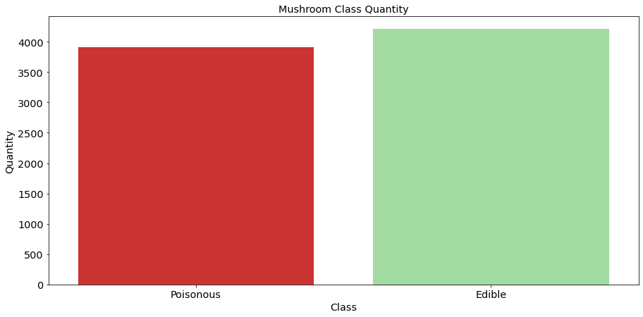

```python
class_dict = ('Poisonous', 'Edible')
plot_col(col='class', labels=class_dict)
```

In the given dataset we have around 3900 poisonous ie p mushrooms and around 4200 edible ie e mushrooms.

Now, let us visualize the number of mushrooms for each cap categorize.

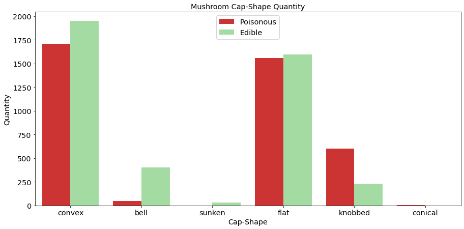

```python
shape_dict = {"bell":"b","conical":"c","convex":"x","flat":"f", "knobbed":"k","sunken":"s"}
labels = ('convex', 'bell', 'sunken', 'flat', 'knobbed', 'conical')
plot_col(col='cap-shape', hue='class', labels=labels)
```

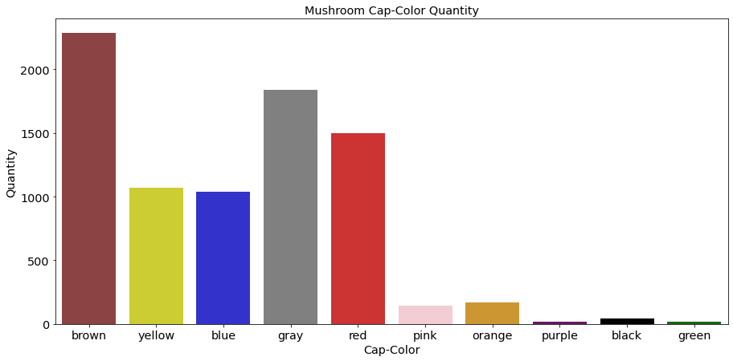

```python
color_dict = {"brown":"n","yellow":"y", "blue":"w", "gray":"g", "red":"e","pink":"p",
              "orange":"b", "purple":"u", "black":"c", "green":"r"}
plot_col(col='cap-color', color=color_dict.keys(), labels=color_dict)
```

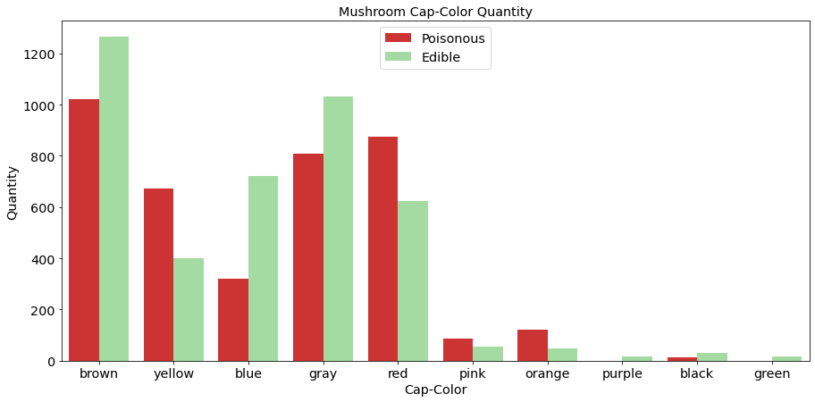

```python
plot_col(col='cap-color', hue='class', labels=color_dict)
```

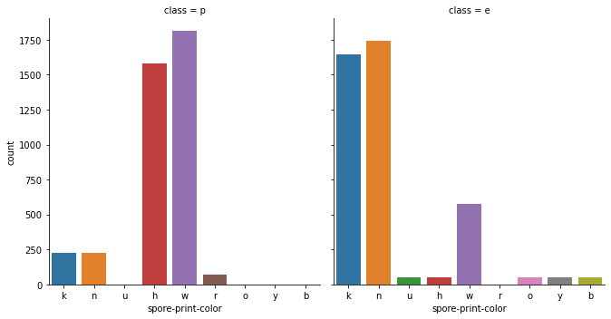

```python
# Now lets see different other coloums counts with class p and e
# 1. number of spore print colour of each class
g = sns.catplot(x="spore-print-color", col="class", col_wrap=4,
            data=dataset,
            kind="count", height=5, aspect=.9)

plt.show()
```

In the Figure above, it is interesting to note that the largest spore-print-color categories for poison mushrooms (Poisonous) are chocolate (h) and white (w), implying that the highest frequency of poisonous mushrooms contains that coloring. Edible mushrooms (Edible) are mostly black (k) and brown (n) in their spores, but even so there is a small existence of edible mushrooms that contain the coloration of chocolate and white spores.

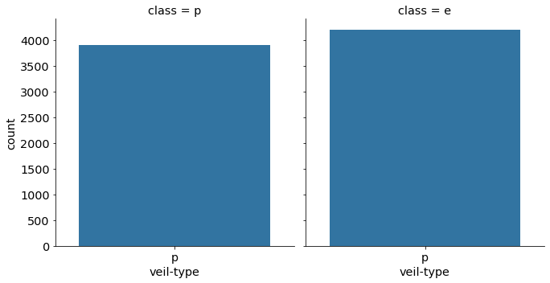

```python
#number of veil-type of each class
g = sns.catplot(x="veil-type", col="class", col_wrap=4,
            data=dataset,
            kind="count", height=5, aspect=.9)
plt.show()
```

We can see that there is olny one veil-type so we can remove this feature

```python
#Now after some eda lets move on to the preprocessing part
# Creating independent and dependent variables
x = dataset.iloc[:,1:].values
y = dataset.iloc[:,0].values
```

Now, let us plot pairwise relationships in a mushrooms for each stalk categorize.

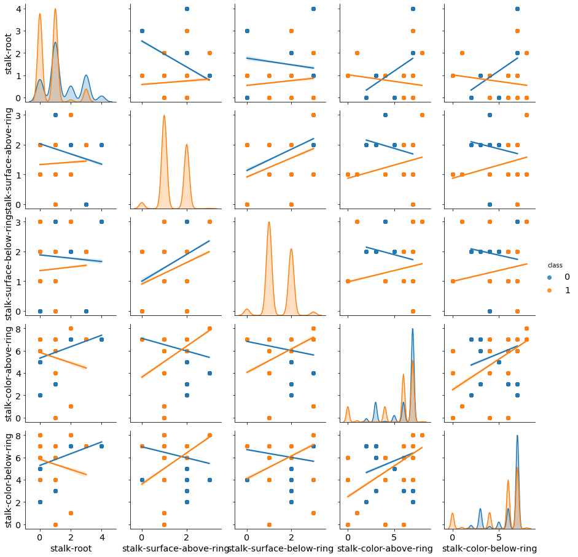

```python
stalk_cats = ['class', 'stalk-root', 'stalk-surface-above-ring', 'stalk-surface-below-ring',
              'stalk-color-above-ring', 'stalk-color-below-ring']
data_cats = data_encoded[stalk_cats]
sns.pairplot(data_cats, hue='class', kind='reg')
```

Let us build pie charts to visualize the Mushroom Population and Habitat Type

```python
def get_labels(order, a_dict):
    labels = []
    for values in order:
        for key, value in a_dict.items():
            if values == value:
                labels.append(key)
    return labels
```

```python
pop_dict = {"abundant":"a","clustered":"c","numerous":"n","scattered":"s","several":"v","solitary":"y"}
hab_dict = {"grasses":"g","leaves":"l","meadows":"m","paths":"p","urban":"u","waste":"w","woods":"d"}
```

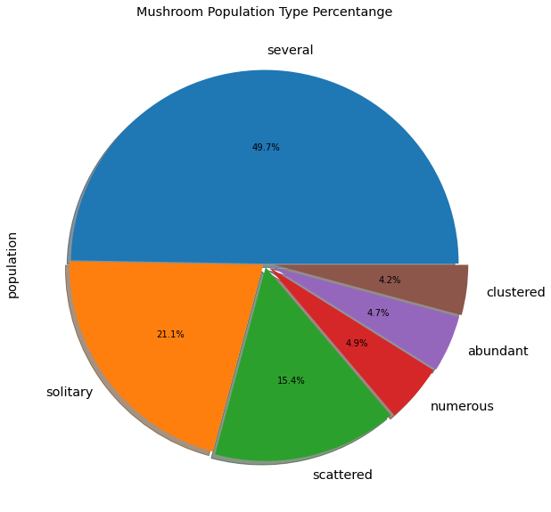

```python
f, ax = plt.subplots(figsize=(15, 10))
order = list(data['population'].value_counts().index)
pop_labels = get_labels(order, pop_dict)
explode = (0.0,0.01,0.02,0.03,0.04,0.05)
data['population'].value_counts().plot.pie(explode=explode , autopct='%1.1f%%', labels=pop_labels, shadow=True, ax=ax)
ax.set_title('Mushroom Population Type Percentange');
```

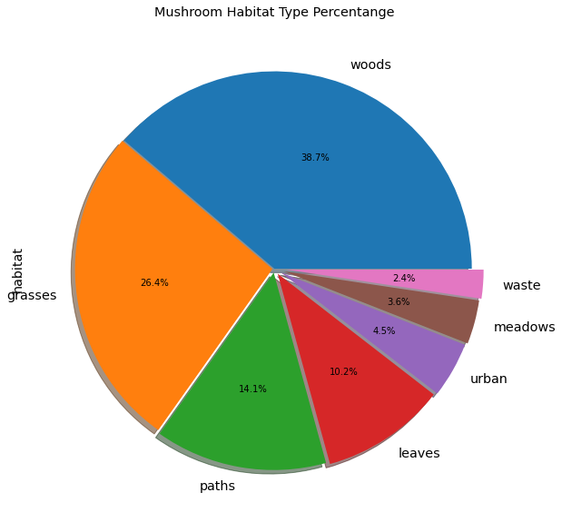

```python
#Mushroom Habitat Type %
f, ax = plt.subplots(figsize=(15, 10))
order = list(data['habitat'].value_counts().index)
hab_labels = get_labels(order, hab_dict)
explode = (0.0,0.01,0.02,0.03,0.04,0.05, 0.06)
data['habitat'].value_counts().plot.pie(explode=explode, autopct='%1.1f%%', labels=hab_labels, shadow=True, ax=ax)
ax.set_title('Mushroom Habitat Type Percentange');
```

Now we can split the data in test train set and then apply different models for acquiring best accuracy

**Splitting the Dataset**

```python
# Splitting the dataset into training set and test set
from sklearn.model_selection import train_test_split
x_train, x_test, y_train, y_test = train_test_split(x, y, test_size = 0.2, random_state=0)
```

**Applying PCA**

```python
# Applying PCA
from sklearn.decomposition import PCA
pca = PCA(n_components = 3)
x_train = pca.fit_transform(x_train)
x_test = pca.transform(x_test)
```

**Model Selection**

```python
from sklearn.linear_model import LogisticRegression
classifier = LogisticRegression(random_state = 0)
classifier.fit(x_train, y_train)
```

```
LogisticRegression(random_state=0)
```

```python
# Predicting the test set
y_pred = classifier.predict(x_test)
```

```python
# Making the confusion matrix and accuracy score
from sklearn.metrics import confusion_matrix, accuracy_score
cm = confusion_matrix(y_test, y_pred)
ac = accuracy_score(y_test, y_pred)
print(cm)
print(ac)
```

```
[[815  37]
 [157 616]]
0.8806153846153846
```

**SVC**

```python
from sklearn.svm import SVC
classifier = SVC(kernel = 'rbf', random_state=0)
classifier.fit(x_train, y_train)
```

```
SVC(random_state=0)
```

```python
# Predicting the test set
y_pred = classifier.predict(x_test)
```

```python
# Making the confusion matrix and accuracy score
from sklearn.metrics import confusion_matrix, accuracy_score
cm = confusion_matrix(y_test, y_pred)
ac = accuracy_score(y_test, y_pred)
print(cm)
print(ac)
```

```
[[815  37]
 [ 24 749]]
0.9624615384615385
```

**Random Forest**

```python
from sklearn.ensemble import RandomForestClassifier
classifier = RandomForestClassifier(criterion = 'entropy', random_state = 0, n_estimators = 100)
classifier.fit(x_train, y_train)
```

```
RandomForestClassifier(criterion='entropy', random_state=0)
```

```python
# Predicting the test set
y_pred = classifier.predict(x_test)
```

```python
# Making the confusion matrix and accuracy score
from sklearn.metrics import confusion_matrix, accuracy_score
cm = confusion_matrix(y_test, y_pred)
ac = accuracy_score(y_test, y_pred)
#acscore.append(ac)
print(cm)
print(ac)
```

```
[[850   2]
 [  2 771]]
0.9975384615384615
```

**XG Boost**

```python
# Training the XGBoost Classification on the Training set
from xgboost import XGBClassifier
classifier = XGBClassifier()
classifier.fit(x_train,y_train)
```

```
XGBClassifier()
```

```python
# Predicting the test set
y_pred = classifier.predict(x_test)
```

```python
# Making the confusion matrix and accuracy score
from sklearn.metrics import confusion_matrix, accuracy_score
cm = confusion_matrix(y_test, y_pred)
ac = accuracy_score(y_test, y_pred)
#acscore.append(ac)
print(cm)
print(ac)
```

```
[[835  17]
 [ 15 758]]
0.9803076923076923
```

It can be concluded that maximum accuracy of 99.75 is obtained using Random Forest Classifier of Sklearn library.

**Using H2O.ai Library**

H2O is a Java-based software for data modeling and general computing. There are many different perceptions of the H2O software, but the primary purpose of H2O is as a distributed (many machines), parallel (many CPUs), in memory (several hundred GBs Xmx) processing engine.

```python
import h2o
```

```python
from h2o.estimators.glm import H2OGeneralizedLinearEstimator
from h2o.estimators.gbm import H2OGradientBoostingEstimator
from h2o.estimators.random_forest import H2ORandomForestEstimator
```

```python
#Initializing h2o
h2o.init()
```

```
Checking whether there is an H2O instance running at http://localhost:54321 . connected.
```

| H2O_cluster_uptime: | 13 mins 56 secs |
| --- | --- |
| H2O_cluster_timezone: | Asia/Kolkata |
| H2O_data_parsing_timezone: | UTC |
| H2O_cluster_version: | 3.32.0.2 |
| H2O_cluster_version_age: | 10 days |
| H2O_cluster_name: | H2O_from_python_Itisha_abnbp7 |
| H2O_cluster_total_nodes: | 1 |
| H2O_cluster_free_memory: | 1.552 Gb |
| H2O_cluster_total_cores: | 8 |
| H2O_cluster_allowed_cores: | 8 |
| H2O_cluster_status: | locked, healthy |
| H2O_connection_url: | http://localhost:54321 |
| H2O_connection_proxy: | {"http": null, "https": null} |
| H2O_internal_security: | False |
| H2O_API_Extensions: | Amazon S3, Algos, AutoML, Core V3, TargetEncoder, Core V4 |
| Python_version: | 3.7.6 final |

**Importing the dataset**

```python
df = h2o.import_file("mushrooms.csv", destination_frame="df")
```

```
Parse progress: |█████████████████████████████████████████████████████████| 100%
```

```python
df.describe()
```

```
Rows:8125
Cols:23
```

|  | C1 | C2 | C3 | C4 | C5 | C6 | C7 | C8 | C9 | C10 | C11 | C12 | C13 | C14 | C15 | C16 | C17 | C18 | C19 | C20 | C21 | C22 | C23 |
| --- | --- | --- | --- | --- | --- | --- | --- | --- | --- | --- | --- | --- | --- | --- | --- | --- | --- | --- | --- | --- | --- | --- | --- |
| type | enum | enum | enum | enum | enum | enum | enum | enum | enum | enum | enum | enum | enum | enum | enum | enum | enum | enum | enum | enum | enum | enum | enum |
| mins |  |  |  |  |  |  |  |  |  |  |  |  |  |  |  |  |  |  |  |  |  |  |  |
| mean |  |  |  |  |  |  |  |  |  |  |  |  |  |  |  |  |  |  |  |  |  |  |  |
| maxs |  |  |  |  |  |  |  |  |  |  |  |  |  |  |  |  |  |  |  |  |  |  |  |
| sigma |  |  |  |  |  |  |  |  |  |  |  |  |  |  |  |  |  |  |  |  |  |  |  |
| zeros |  |  |  |  |  |  |  |  |  |  |  |  |  |  |  |  |  |  |  |  |  |  |  |
| missing | 0 | 0 | 0 | 0 | 0 | 0 | 0 | 0 | 0 | 0 | 0 | 0 | 0 | 0 | 0 | 0 | 0 | 0 | 0 | 0 | 0 | 0 | 0 |
| 0 | class | cap-shape | cap-surface | cap-color | bruises | odor | gill-attachment | gill-spacing | gill-size | gill-color | stalk-shape | stalk-root | stalk-surface-above-ring | stalk-surface-below-ring | stalk-color-above-ring | stalk-color-below-ring | veil-type | veil-color | ring-number | ring-type | spore-print-color | population | habitat |
| 1 | p | x | s | n | t | p | f | c | n | k | e | e | s | s | w | w | p | w | o | p | k | s | u |
| 2 | e | x | s | y | t | a | f | c | b | k | e | c | s | s | w | w | p | w | o | p | n | n | g |
| 3 | e | b | s | w | t | l | f | c | b | n | e | c | s | s | w | w | p | w | o | p | n | n | m |
| 4 | p | x | y | w | t | p | f | c | n | n | e | e | s | s | w | w | p | w | o | p | k | s | u |
| 5 | e | x | s | g | f | n | f | w | b | k | t | e | s | s | w | w | p | w | o | e | n | a | g |
| 6 | e | x | y | y | t | a | f | c | b | n | e | c | s | s | w | w | p | w | o | p | k | n | g |
| 7 | e | b | s | w | t | a | f | c | b | g | e | c | s | s | w | w | p | w | o | p | k | n | m |
| 8 | e | b | y | w | t | l | f | c | b | n | e | c | s | s | w | w | p | w | o | p | n | s | m |
| 9 | p | x | y | w | t | p | f | c | n | p | e | e | s | s | w | w | p | w | o | p | k | v | g |

**Splitting The Dataset**

```python
train, valid, test = df.split_frame(ratios=[0.6,0.2], seed=1234)
response = "C1"
train[response] = train[response].asfactor()
valid[response] = valid[response].asfactor()
test[response] = test[response].asfactor()
print("Number of rows in train, valid and test set : ", train.shape[0], valid.shape[0], test.shape[0])
```

```
Number of rows in train, valid and test set :  4873 1639 1613
```

**Modeling and Model Tuning :**

Now, let us build a baseline model using these splits. There are multiple algorithms available in the H2O module. We can start with the Kaggler's favorite - GBM.

Please note that the target variable is "Class" and rest of the features are as input features. Since this is a baseline model, let us use the default parameters.

```python
predictors = df.columns[1:]
gbm = H2OGradientBoostingEstimator()
gbm.train(x=predictors, y=response, training_frame=train)
```

```
gbm Model Build progress: |███████████████████████████████████████████████| 100%
```

Again, it is good to see the model building progress.

Now let us do a print(model_name) to understand more about the model

```python
print(gbm)
```

```
Model Details
=============
H2OGradientBoostingEstimator :  Gradient Boosting Machine
Model Key:  GBM_model_python_1606554520877_1


Model Summary:
```

|  |  | number_of_trees | number_of_internal_trees | model_size_in_bytes | min_depth | max_depth | mean_depth | min_leaves | max_leaves | mean_leaves |
| --- | --- | --- | --- | --- | --- | --- | --- | --- | --- | --- |
| 0 |  | 50.0 | 100.0 | 15008.0 | 5.0 | 5.0 | 5.0 | 7.0 | 10.0 | 7.31 |

```
ModelMetricsMultinomial: gbm
** Reported on train data. **

MSE: 0.00035754546753024734
RMSE: 0.018908872719711436
LogLoss: 0.015284523659495515
Mean Per-Class Error: 0.00014405070584845865

Confusion Matrix: Row labels: Actual class; Column labels: Predicted class
```

|  | class | e | p | Error | Rate |
| --- | --- | --- | --- | --- | --- |
| 0 | 0.0 | 0.0 | 0.0 | NaN | 0 / 0 |
| 1 | 0.0 | 2559.0 | 0.0 | 0.000000 | 0 / 2,559 |
| 2 | 0.0 | 1.0 | 2313.0 | 0.000432 | 1 / 2,314 |
| 3 | 0.0 | 2560.0 | 2313.0 | 0.000205 | 1 / 4,873 |

```
Top-3 Hit Ratios:
```

|  | k | hit_ratio |
| --- | --- | --- |
| 0 | 1 | 0.999795 |
| 1 | 2 | 1.000000 |
| 2 | 3 | 1.000000 |

```
Scoring History:
```

|  |  | timestamp | duration | number_of_trees | training_rmse | training_logloss | training_classification_error |
| --- | --- | --- | --- | --- | --- | --- | --- |
| 0 |  | 2020-11-28 14:53:16 | 0.110 sec | 0.0 | 0.666667 | 1.098612 | 0.493331 |
| 1 |  | 2020-11-28 14:53:16 | 0.502 sec | 1.0 | 0.609393 | 0.940061 | 0.000410 |
| 2 |  | 2020-11-28 14:53:16 | 0.560 sec | 2.0 | 0.557490 | 0.815315 | 0.000410 |
| 3 |  | 2020-11-28 14:53:16 | 0.607 sec | 3.0 | 0.510359 | 0.714123 | 0.000410 |
| 4 |  | 2020-11-28 14:53:16 | 0.643 sec | 4.0 | 0.467517 | 0.630261 | 0.000410 |
| 5 |  | 2020-11-28 14:53:16 | 0.699 sec | 5.0 | 0.428550 | 0.559650 | 0.000410 |
| 6 |  | 2020-11-28 14:53:16 | 0.739 sec | 6.0 | 0.393091 | 0.499458 | 0.000410 |
| 7 |  | 2020-11-28 14:53:16 | 0.790 sec | 7.0 | 0.360809 | 0.447641 | 0.000410 |
| 8 |  | 2020-11-28 14:53:16 | 0.834 sec | 8.0 | 0.331408 | 0.402671 | 0.000410 |
| 9 |  | 2020-11-28 14:53:16 | 0.876 sec | 9.0 | 0.304617 | 0.363380 | 0.000410 |
| 10 |  | 2020-11-28 14:53:16 | 0.924 sec | 10.0 | 0.280194 | 0.328853 | 0.000410 |
| 11 |  | 2020-11-28 14:53:16 | 0.948 sec | 11.0 | 0.257918 | 0.298362 | 0.000410 |
| 12 |  | 2020-11-28 14:53:16 | 0.982 sec | 12.0 | 0.237589 | 0.271317 | 0.000410 |
| 13 |  | 2020-11-28 14:53:16 | 1.014 sec | 13.0 | 0.219028 | 0.247236 | 0.000410 |
| 14 |  | 2020-11-28 14:53:17 | 1.043 sec | 14.0 | 0.202070 | 0.225722 | 0.000410 |
| 15 |  | 2020-11-28 14:53:17 | 1.075 sec | 15.0 | 0.186569 | 0.206443 | 0.000410 |
| 16 |  | 2020-11-28 14:53:17 | 1.101 sec | 16.0 | 0.172391 | 0.189115 | 0.000410 |
| 17 |  | 2020-11-28 14:53:17 | 1.134 sec | 17.0 | 0.159417 | 0.173507 | 0.000410 |
| 18 |  | 2020-11-28 14:53:17 | 1.167 sec | 18.0 | 0.147538 | 0.159408 | 0.000410 |
| 19 |  | 2020-11-28 14:53:17 | 1.199 sec | 19.0 | 0.136655 | 0.146652 | 0.000410 |

```
See the whole table with table.as_data_frame()

Variable Importances:
```

|  | variable | relative_importance | scaled_importance | percentage |
| --- | --- | --- | --- | --- |
| 0 | C6 | 12513.879883 | 1.000000e+00 | 9.436328e-01 |
| 1 | C21 | 475.741913 | 3.801714e-02 | 3.587422e-02 |
| 2 | C16 | 181.695587 | 1.451952e-02 | 1.370110e-02 |
| 3 | C12 | 48.804424 | 3.900023e-03 | 3.680190e-03 |
| 4 | C13 | 37.390469 | 2.987920e-03 | 2.819499e-03 |
| 5 | C4 | 1.295721 | 1.035427e-04 | 9.770626e-05 |
| 6 | C9 | 0.967182 | 7.728870e-05 | 7.293216e-05 |
| 7 | C2 | 0.739176 | 5.906847e-05 | 5.573895e-05 |
| 8 | C23 | 0.557606 | 4.455901e-05 | 4.204735e-05 |
| 9 | C22 | 0.153941 | 1.230164e-05 | 1.160823e-05 |
| 10 | C19 | 0.103393 | 8.262293e-06 | 7.796571e-06 |
| 11 | C14 | 0.018353 | 1.466642e-06 | 1.383971e-06 |
| 12 | C15 | 0.013284 | 1.061538e-06 | 1.001702e-06 |
| 13 | C7 | 0.010641 | 8.503194e-07 | 8.023893e-07 |
| 14 | C3 | 0.008586 | 6.860859e-07 | 6.474132e-07 |
| 15 | C18 | 0.006734 | 5.380936e-07 | 5.077627e-07 |
| 16 | C5 | 0.000000 | 0.000000e+00 | 0.000000e+00 |
| 17 | C8 | 0.000000 | 0.000000e+00 | 0.000000e+00 |
| 18 | C10 | 0.000000 | 0.000000e+00 | 0.000000e+00 |
| 19 | C11 | 0.000000 | 0.000000e+00 | 0.000000e+00 |

```
See the whole table with table.as_data_frame()
```

```python
perf = gbm.model_performance(valid)
print(perf)
```

```
ModelMetricsMultinomial: gbm
** Reported on test data. **

MSE: 0.0012128451914316801
RMSE: 0.034825927000320896
LogLoss: 0.018520722133662914
Mean Per-Class Error: 0.33375

Confusion Matrix: Row labels: Actual class; Column labels: Predicted class
```

|  | class | e | p | Error | Rate |
| --- | --- | --- | --- | --- | --- |
| 0 | 0.0 | 0.0 | 1.0 | 1.00000 | 1 / 1 |
| 1 | 0.0 | 838.0 | 0.0 | 0.00000 | 0 / 838 |
| 2 | 0.0 | 1.0 | 799.0 | 0.00125 | 1 / 800 |
| 3 | 0.0 | 839.0 | 800.0 | 0.00122 | 2 / 1,639 |

```
Top-3 Hit Ratios:
```

|  | k | hit_ratio |
| --- | --- | --- |
| 0 | 1 | 0.99878 |
| 1 | 2 | 1.00000 |
| 2 | 3 | 1.00000 |

Now we can use the validation set to tune our parameters. We can use the early stopping to find the number of iterations to train similar to other GBM implementations. We can set some random values for the parameters to start with. Please note that, we have added a new validation_frame parameter in this one compared to the previous one while training.

```python
gbm_tune = H2OGradientBoostingEstimator(
    ntrees = 3000,
    learn_rate = 0.01,
    stopping_rounds = 20,
    #stopping_metric = "AUC",
    col_sample_rate = 0.7,
    sample_rate = 0.7,
    seed = 1234
)
gbm_tune.train(x=predictors, y=response, training_frame=train, validation_frame=valid)
```

```
gbm Model Build progress: |███████████████████████████████████████████████| 100%
```

```python
gbm_tune.model_performance(valid)
```

```
ModelMetricsMultinomial: gbm
** Reported on test data. **

MSE: 4.550991675202787e-05
RMSE: 0.006746103820134098
LogLoss: 0.00019465234065144267
Mean Per-Class Error: 0.0

Confusion Matrix: Row labels: Actual class; Column labels: Predicted class
```

|  | class | e | p | Error | Rate |
| --- | --- | --- | --- | --- | --- |
| 0 | 1.0 | 0.0 | 0.0 | 0.0 | 0 / 1 |
| 1 | 0.0 | 838.0 | 0.0 | 0.0 | 0 / 838 |
| 2 | 0.0 | 0.0 | 800.0 | 0.0 | 0 / 800 |
| 3 | 1.0 | 838.0 | 800.0 | 0.0 | 0 / 1,639 |

```
Top-3 Hit Ratios:
```

|  | k | hit_ratio |
| --- | --- | --- |
| 0 | 1 | 1.0 |
| 1 | 2 | 1.0 |
| 2 | 3 | 1.0 |

**AutoML : Automatic Machine Learning:**

H2O’s AutoML can be used for automating the machine learning workflow, which includes automatic training and tuning of many models within a user-specified time-limit. Stacked Ensembles will be automatically trained on collections of individual models to produce highly predictive ensemble models which, in most cases, will be the top performing models in the AutoML Leaderboard.

So let us use the H2OAutoML function to do automatic machine learning.

```python
from h2o.automl import H2OAutoML

aml = H2OAutoML(max_models = 10, max_runtime_secs=100, seed = 1)
aml.train(x=predictors, y=response, training_frame=train, validation_frame=valid)
```

```
AutoML progress: |█
14:54:18.952: User specified a validation frame with cross-validation still enabled. Please note that the models will still be validated using cross-validation only, the validation frame will be used to provide purely informative validation metrics on the trained models.
14:54:19.15: AutoML: XGBoost is not available; skipping it.

███████████████████████████████████████████████████████| 100%
```

```python
lb = aml.leaderboard
lb
```

| model_id | mean_per_class_error | logloss | rmse | mse |
| --- | --- | --- | --- | --- |
| DRF_1_AutoML_20201128_145418 | 0 | 0.00223014 | 0.011779 | 0.000138746 |
| GBM_1_AutoML_20201128_145418 | 0.000144051 | 0.0478001 | 0.0499254 | 0.00249254 |
| GBM_2_AutoML_20201128_145418 | 0.000288101 | 0.0625521 | 0.0626307 | 0.00392261 |
| GBM_4_AutoML_20201128_145418 | 0.000288101 | 0.0620638 | 0.0619146 | 0.00383342 |
| GBM_grid__1_AutoML_20201128_145418_model_1 | 0.000288101 | 0.0638928 | 0.0644305 | 0.00415129 |
| GBM_3_AutoML_20201128_145418 | 0.000288101 | 0.0625209 | 0.0624486 | 0.00389983 |
| XRT_1_AutoML_20201128_145418 | 0.000390778 | 0.190649 | 0.191726 | 0.0367587 |
| GBM_5_AutoML_20201128_145418 | 0.000720254 | 0.0372573 | 0.0529844 | 0.00280735 |
| DeepLearning_1_AutoML_20201128_145418 | 0.000864304 | 0.00338851 | 0.0293301 | 0.000860255 |
| GLM_1_AutoML_20201128_145418 | 0.326995 | 0.66786 | 0.487223 | 0.237387 |

AutoML has built variety of models inlcuding GBM, GLM, Deep Learning and XRT (Extremely Randomized Trees) and the best model is a DRF

**Conclusion:**

Using H2o.ai, we are successful in acquiring a perfect accuracy of 100% using GBM after performing some hyperparameter tuning.

When it comes to available machine learning algorithms, H2O has a nice set of available algorithms for users to leverage.

**Supervised Learning:** Deep Learning (Neural Networks), Distributed Random Forest (DRF), Generalized Linear Model (GLM), Gradient Boosting Machine (GBM), Naïve Bayes Classifier, Stacked Ensembles, XGBoost

**Unsupervised:** Aggregagtor, Generalized Low Rank Models (GLRM), K-Means Clustering, Principal Component Analysis (PCA)

**Others:** Quantiles, Early Stopping, Word2Vec

**H2O - Key Features:**

Some of the key features

1.Access from both R and Python

2.Access from web-based interface named Flow. By means of Flow, data scientists are able to import, explore, and modify datasets, play with models, verify models performances, and much more.

3.AutoML : automatic training and tuning of many models within a user-specified time-limit.

4.Distributed, In-memory processing : In-memory processing with fast serialization between nodes and clusters to support massive datasets.

5.Simple Deployment : Easy to deploy POJOs and MOJOs to deploy models for fast and accurate scoring in any environment, including with very large models.

Therefore we can conclude that its the unique features and presence of immense machine learning models which make H2o.ai a wonderful and extremely useful library.